# BIOS 667 - Lecture 16: Contrasting Marginal and Mixed Effects Models

## Check Your Understanding: ECG Case Study

**Question:** The ECG study shows a GEE OR of 1.77 and a GLMM OR of 6.44. A colleague asks: “Which one is the true effect?”

**How should you respond?**

**Answer:** There is no single “true effect” – both estimates are correct for their respective estimands.

**Key points to explain:**

1. **Different questions:** GEE answers “What happens on average in the population?” while GLMM answers “What happens within a given individual?”
2. **Non-collapsibility:** For binary outcomes, marginal and conditional ORs are mathematically different even without confounding. This is a property of odds ratios, not a flaw in either method.
3. **Practical guidance:** Report the GEE estimate for regulatory submissions (population benefit). Report the GLMM estimate for clinical decision-making (individual risk). If unsure, report both with clear interpretation.
4. **The difference is expected:** The GLMM OR being larger is consistent with attenuation theory. The marginal effect is always closer to 1 (null) due to averaging over heterogeneity.

## Non-collapsibility in Numbers (no confounding)

Two subgroups of equal size, conditional (within-subgroup) OR = $9$ in **both** (so nothing is confounded):

| Subgroup | Treated $P(Y=1)$ | Control $P(Y=1)$ | Conditional OR |
| --- | --- | --- | --- |
| Low-risk | 0.50 | 0.10 | $\frac{.5/.5}{.1/.9}=9$ |
| High-risk | 0.90 | 0.50 | $\frac{.9/.1}{.5/.5}=9$ |
| **Pooled (marginal)** | 0.70 | 0.30 | $\frac{.7/.3}{.3/.7}=5.44$ |

Marginal OR $= 5.44 \neq 9 =$ conditional OR, with **no confounder**. The odds ratio is **non-collapsible**$^\dagger$.

## Which to Report?

| Context | Report | Reason |
| --- | --- | --- |
| Clinical Study Report (CSR) for FDA | GEE estimate | Population-level inference |
| Patient counseling | GLMM estimate | Individual-level inference |

**Both are correct – they answer different questions!**

## 16.5 Small-Sample GEE Variance Adjustments

With only 2 observations per subject, standard GEE robust SEs can be biased downward.

```r
# Option 1: Jackknife standard errors
gee_jack <- geepack::geeglm(
  response ~ treatment + period, id = id,
  family = binomial, corstr = "exchangeable",
  data = ecg_long, std.err = "jack"
)

# Option 2: CR2 correction via clubSandwich
library(clubSandwich)
gee_cr2 <- coef_test(gee_fit, vcov = "CR2", cluster = ecg_long$id)

# Option 3: Fay correction
gee_fay <- geepack::geeglm(
  response ~ treatment + period, id = id,
  family = binomial, corstr = "exchangeable",
  data = ecg_long, std.err = "fay"
)
```

**Note**: These corrections typically increase SEs by 10-30% with small clusters.

## 16.5 Structured Comparison

| Aspect | Marginal (GEE) | Mixed (GLMM) |
| --- | --- | --- |
| OR estimate | 1.77 | 6.44 |
| Standard error | 0.23 | 0.93 |
| Answers question | Population-level | Individual-level |
| Interpretation | Population odds increase 77% | Individual odds increase 544% |
| Regulatory use | Phase III efficacy claims | Personalized medicine |
| Sensitivity to $\sigma_b^2$ | Relatively insensitive | Very sensitive |

## 16.5 OR Contrast Visualization

```r
or_plot <- ggplot(contrast_tbl, aes(x = model, y = odds_ratio)) +
  geom_pointrange(aes(ymin = lower, ymax = upper), size = 0.9, color = "#1f65b7") +
  geom_hline(yintercept = 1, linetype = "dashed", color = "gray40") +
  scale_y_log10(breaks = c(0.5, 1, 2, 4, 8, 16)) +
  coord_flip() +
  labs(
    x = NULL,
    y = "Treatment odds ratio (Active vs Placebo)",
    title = "Population vs subject-specific treatment effects",
    subtitle = "Same data, different estimands -- both valid for their intended use"
  ) +
  theme_minimal(base_size = 16)
print(or_plot)
```

## 16.5 OR Contrast Visualization

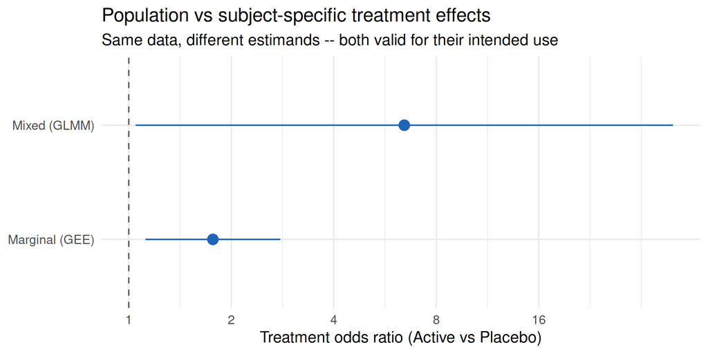

Both estimates are correct – they answer different questions. The difference reflects attenuation theory.

## 16.5 The Sampling Zero Problem

**Observation**: ECG data has ZERO in cell (Sequence P-A, response pattern 1,0).

**Why this matters**:

| Issue | Impact |
| --- | --- |
| Sampling zero | Can destabilize estimation |
| GLMMs especially sensitive | Quadrature-based estimation struggles |
| FLW sensitivity practice (p. 483) | Add $1/4$ to the **single sampling-zero cell only**, then refit |

FLW’s sensitivity refits (add $1/4$ to the (P-A, 1,0) cell): marginal Treatment $\approx 0.55$, GLMM Treatment $\approx 1.64$, $\widehat{g}_{11} \approx 20.7$ - substantive conclusions unchanged.

## Alternatives to Continuity Correction

| Method | Description |
| --- | --- |
| Penalized likelihood | Firth correction |
| Bayesian methods | Weakly informative priors |
| Conditional logistic | For paired data |

**Key point**: The 0.25 correction is a **diagnostic probe**, not a solution.

## 16.5 Robustness Check with Conditional Logistic

```r
# Conditional logistic (fixed-effects / within-subject), stratified by subject.
# In a 2-period crossover, treatment and period are confounded WITHIN subject,
# so we condition on subject and estimate the treatment effect alone; adding
# period to the conditional model is not separately identified here.
clogit_fit <- survival::clogit(
  response ~ treatment + strata(id),
  data = ecg_long
)

clogit_or <- exp(coef(clogit_fit)["treatment"])
cat("Conditional logistic OR for treatment:", round(clogit_or, 2), "\n")
```

**Note**

In the Section 16.5 case study, FLW instead uses conditional ML (the method of Section 14.6) **after** adding $1/4$ to the sampling-zero cell, obtaining $\widehat\beta_2^* = 1.94$ (close to the GLMM’s $1.86$), with a Hausman-type test (Tchetgen & Coull 2006, Section 14.6) giving $Z = 0.40$ ($p > 0.65$): no evidence against the normal random-effects assumption.

## 16.5 Robustness Check with Conditional Logistic

```
Conditional logistic OR for treatment: 5
```

```r
cat("Compare to GLMM OR:", round(contrast_tbl$odds_ratio[2], 2), "\n")
```

```
Compare to GLMM OR: 6.44
```

```r
cat("\nSame direction and order of magnitude as the GLMM:",
    "the subject-specific effect is robust to the normal-b_i assumption.\n")
```

```
Same direction and order of magnitude as the GLMM: the subject-specific effect is robust to the normal-b_i assumption.
```

## 16.5 Additional Diagnostics

**For sparse data with small $n_i$:**

| Check | Purpose |
| --- | --- |
| Separation issues | Logistic models can fail to converge |
| Exact logistic regression | For small samples |
| Random effects distribution | Sensitivity to normality assumption |
| Profile likelihood CIs | When Wald approximation is questionable |

## Key Messages for Sparse Data

- Distributional assumptions on $b_i$ matter most when $n_i$ is small
- With only 2 observations/subject, both approaches have limitations
- Report sensitivity analyses alongside main results

## 16.6 Conclusion Highlights

| Approach | Focus | Use Case |
| --- | --- | --- |
| Marginal | $\mu_i$; model mean and association separately | Policy, regulatory |
| Mixed | Individual trajectories; random effects explain correlation | Personalized medicine |

**Key insight**: Mixed models do NOT automatically provide marginal summaries without extra integration.

## 16.6 No Grand Unified Model

FLW’s verdict: do not chase one model that answers every question. Different scientific questions demand different models.

> “The megalomaniacal strategy of fitting a grand unified model… is dangerous, unnecessary and counterproductive.” – Drum & McCullagh (1993), quoted approvingly by FLW (p. 486)

**One size does not fit all.** Choose marginal or mixed by the question, and report both when the audience needs both.

## Why GLMMs Do Not Solve Everything

| Issue | Explanation |
| --- | --- |
| Marginal means derivable *in principle* | But link forms change |
| Misspecified random effects | Lead to biased population averages |
| Marginal models | Avoid that risk when target is population inference |

**Bottom line**: One size does not fit all.

## When to Choose Marginal vs Mixed Models

| Scenario | Use Marginal (GEE) | Use Mixed (GLMM) |
| --- | --- | --- |
| FDA submission | X |  |
| Public health policy | X |  |
| Population attributable risk | X |  |
| Personalized medicine |  | X |
| Risk calculators |  | X |
| Individual prediction |  | X |
| Mechanistic understanding |  | X |

**Can you fit both?** YES! Report both when stakeholders need both estimands.

## Common Misconceptions

| Misconception | Reality |
| --- | --- |
| “Mixed models are always better” | They answer different questions; GEE optimal for marginal inference |
| “The GLMM $\beta^*$ is biased because it’s larger” | Neither biased – they estimate different parameters |
| “`re.form = NA` gives marginal predictions” | NO! It gives $E[Y \mid b=0]$, not $E[Y]$. Must integrate over $f(b)$. |

## More Misconceptions

| Misconception | Reality |
| --- | --- |
| “Link function preserved after integration” | Only for identity (linear) and partially for log link |
| “Large SEs in GLMM indicate problems” | Expected with small $n_i$ or large $\sigma_b^2$ |

## Common Software Pitfalls

| Warning Sign | What to Do |
| --- | --- |
| Default options may not match your estimand | Check documentation |
| `glmer` and `geeglm` syntax similarity | Remember they target different quantities |
| `predict(glmer, re.form = NA)` $\neq$ marginal prediction | Gives $E[Y \mid b=0]$, not $E[Y]$; use Monte Carlo integration |
| Convergence warnings with small clusters | Try different optimizers |
| Sparse cells | Require sensitivity analyses |
| High $\sigma_b^2$ | Check quadrature points in GLMMs |

## Best Practices

1. State estimand before opening software
2. Check for sparse cells in contingency tables
3. Use proper integration for marginal predictions from GLMMs
4. Apply small-sample corrections for GEE with few clusters
5. Report both estimates when relevant

## Common Mistakes When Contrasting Models

| Mistake | Why It Is Wrong | Correction |
| --- | --- | --- |
| Claiming GLMM is “biased” because OR differs from GEE | They estimate different parameters (conditional vs marginal) | Both are unbiased for their respective estimands |
| Expecting GEE and GLMM to match for binary outcomes | Non-collapsibility makes this impossible | Accept the difference as mathematically expected |
| Using `re.form=NA` for “marginal” predictions | This gives $E[Y \mid b=0]$, not $E[Y]$ | Use Monte Carlo integration over $f(b)$ |
| Choosing model based on which gives “better” p-value | P-value shopping invalidates inference | Choose model based on research question before seeing results |
| Ignoring small-sample issues in GEE | Robust SE can be biased downward with few clusters | Use jackknife, CR2, or Fay corrections |
| Fitting only one model type | Different audiences need different estimands | Fit both GEE and GLMM as sensitivity analysis |

## Check Your Understanding: Model Selection

**Scenario:** You are analyzing a clinical trial of a new antidepressant. The outcome is binary (remission yes/no) measured at 4 visits. You must present results to:

1. The FDA for drug approval
2. Psychiatrists who will prescribe the drug

**Question:** What model(s) should you fit, and what should you report to each audience?

**Answer:**

**Fit both models:**

- GEE with exchangeable working correlation and robust SE
- GLMM with random intercept (and possibly random slope for time)

**Report to FDA:**

- GEE estimate (population-average OR)
- “Treatment increased the population odds of remission by X% (OR = Y, 95% CI: …)”
- Focus on: Did it work for the population?

**Report to psychiatrists:**

- GLMM estimate (subject-specific OR)
- “For any given patient, treatment increases their odds of remission by X% (OR = Y, 95% CI: …)”
- Also mention random intercept SD to convey patient-to-patient variability
- Focus on: Will it work for my patient?

**In the paper:** Report both, clearly labeled, with explanation of why they differ.

## Advanced (beyond FLW): Marginalized Mixed Models

**The challenge:** want BOTH random effects (heterogeneity) AND a direct marginal interpretation. FLW notes this is possible only with a **non-standard** conditional-mean specification (footnote, p. 478); the constructions themselves are beyond Ch. 16.

| Approach | Reference |
| --- | --- |
| Marginalized multilevel / mixed models | Heagerty (1999); Heagerty & Zeger (2000) |
| h-likelihood methods | Lee & Nelder (2004) |
| Implementations | Swihart et al. (2014) |

**Trade-off:** best of both worlds in theory, but complex, specialized software, computationally intensive.

## Recipe Card: Decision Table

**Step 1 - Define the estimand, then read across:**

| Factor | Favors Marginal (GEE) | Favors Mixed (GLMM) |
| --- | --- | --- |
| Target of inference | Population-average | Subject-specific |
| Typical audience | FDA, public health | Clinicians, precision medicine |
| Key output | Population OR/RR, attributable risk | Conditional OR/RR, RE variance |
| Cluster size $n_i$ | Small (2-4) | Larger (5+) |
| Missing data | MCAR (or IPW-GEE for MAR) | MAR (likelihood) |
| Random effects of interest | No | Yes |
| Concern about RE distribution | Yes | Less so |

**Warning**

**Missing data (FLW p. 528).** *Standard* GEE requires **MCAR**. **IPW-GEE** (correct dropout model) extends GEE to **MAR**; likelihood-based GLMMs are valid under **MAR** without weighting. “MCAR favors GEE” means *standard* GEE.

## Recipe Card: Decision Flowchart

```
                    START
            What is your estimand?
           /                      \
    Population effect          Individual effect
          |                           |
      Use GEE                     Use GLMM
          |                           |
   Report population OR/RR     Report conditional OR/RR
          |                           |
   Consider: robust SE,        Consider: nAGQ, random-
   working correlation, MCAR   effects structure, MAR
          |                           |
          +----------+----------------+
        Report BOTH if the audience includes
        clinicians AND regulators
```

**Methods-section template:** *“We used [GEE/GLMM] because our primary interest was [population-average/subject-specific] effects.”*

## Synthesis and Key Takeaways

1. **Estimand clarity prevents misinterpretation** – Know your audience
2. **Linear models are special** – Only place where $\beta = \beta^*$
3. **Attenuation is predictable** – Use formula (for logistic random-intercept models)
4. **Both approaches are valid** – Different questions need different models
5. **Marginal predictions require integration** – `re.form = NA` gives $E[Y \mid b=0]$, NOT $E[Y]$

**Remember**: The model serves the question, not vice versa.

## 16.7 Further Reading

**Most accessible**:

| Reference | Best for |
| --- | --- |
| Hubbard et al. (2010) | Clinical researchers |
| Agresti (2002, Section 12.2) | Clearest binary data explanation |

**Comprehensive coverage**:

| Reference | Topic |
| --- | --- |
| Fitzmaurice et al. (2009, Ch. 7) | Detailed targets of inference |
| Gardiner et al. (2009) | Assumption comparison checklist |

## Further Reading: Technical Foundations

| Reference | Topic |
| --- | --- |
| Neuhaus et al. (1991) | Original comparison paper |
| Zeger et al. (1988) | Population-average GEE theory |
| Heagerty & Zeger (2000) | Marginalized mixed models |

## Summary Checklist

Before analyzing longitudinal/clustered data, ask:

- What is my primary research question?
- Who is my audience (regulator, clinician, patient)?
- Do I need population or individual inference?
- Is my outcome linear or non-linear?
- How much heterogeneity exists ($\sigma_b^2$)?
- Do I have sparse cells or small clusters?
- Am I computing marginal predictions correctly?
- Should I report both marginal and conditional estimates?

## Final Thought

Understanding the distinction between marginal and conditional models is essential for correct inference in longitudinal data analysis.